Victor Omondi | Blog

# Tidying data

Oct 19, 2020 • 45 min read

[figure not shown]

# Introduction and Exproling Raw data

An overview of the process of data cleaning with R and the basics of exploring raw data.

## Introduction to Cleaning Data in R

## The Essential Parts of a Data Cleaning Process

1. Exploring raw data
2. Tidying data
3. Preparing data for analysis

> No one likes missing data, but it is dangerous to assume that it can simply be removed or replaced. Sometimes missing data tells us something important about whatever it is that we're measuring (i.e. the value of the variable that is missing may be related to - the reason it is missing). Such data is called Missing not at Random, or MNAR.

We are presented with a messy, real-world dataset containing an entire year's worth of weather data from Boston, USA. Among other things, we'll be presented with variables that contain column names, column names that should be values, numbers coded as character strings, and values that are missing, extreme, and downright erroneous!

## Exploring raw data

### Getting a feel for your data

```python
library(readr)
library(dplyr)
library(lubridate)
library(stringr)
library(installr)
```

```python
weather = readRDS(gzcon(url('https://assets.datacamp.com/production/repositories/34/datasets/b3c1036d9a60a9dfe0f99051d2474a54f76055ea/weather.rds')))
```

```python
class(weather)
```

'data.frame'

```python
head(weather)
```

| X | year | month | measure | X1 | X2 | X3 | X4 | X5 | X6 | ... | X22 | X23 | X24 | X25 | X26 | X27 | X28 | X29 | X30 | X31 |
| --- | --- | --- | --- | --- | --- | --- | --- | --- | --- | --- | --- | --- | --- | --- | --- | --- | --- | --- | --- | --- |
| 1 | 2014 | 12 | Max.TemperatureF | 64 | 42 | 51 | 43 | 42 | 45 | ... | 44 | 47 | 46 | 59 | 50 | 52 | 52 | 41 | 30 | 30 |
| 2 | 2014 | 12 | Mean.TemperatureF | 52 | 38 | 44 | 37 | 34 | 42 | ... | 39 | 45 | 44 | 52 | 44 | 45 | 46 | 36 | 26 | 25 |
| 3 | 2014 | 12 | Min.TemperatureF | 39 | 33 | 37 | 30 | 26 | 38 | ... | 33 | 42 | 41 | 44 | 37 | 38 | 40 | 30 | 22 | 20 |
| 4 | 2014 | 12 | Max.Dew.PointF | 46 | 40 | 49 | 24 | 37 | 45 | ... | 39 | 45 | 46 | 58 | 31 | 34 | 42 | 26 | 10 | 8 |
| 5 | 2014 | 12 | MeanDew.PointF | 40 | 27 | 42 | 21 | 25 | 40 | ... | 34 | 42 | 44 | 43 | 29 | 31 | 35 | 20 | 4 | 5 |
| 6 | 2014 | 12 | Min.DewpointF | 26 | 17 | 24 | 13 | 12 | 36 | ... | 25 | 37 | 41 | 29 | 28 | 29 | 27 | 10 | -6 | 1 |

```python
tail(weather)
```

|  | X | year | month | measure | X1 | X2 | X3 | X4 | X5 | X6 | ... | X22 | X23 | X24 | X25 | X26 | X27 | X28 | X29 | X30 | X31 |
| --- | --- | --- | --- | --- | --- | --- | --- | --- | --- | --- | --- | --- | --- | --- | --- | --- | --- | --- | --- | --- | --- |
| 281 | 281 | 2015 | 12 | Mean.Wind.SpeedMPH | 6 | NA | NA | NA | NA | NA | ... | NA | NA | NA | NA | NA | NA | NA | NA | NA | NA |
| 282 | 282 | 2015 | 12 | Max.Gust.SpeedMPH | 17 | NA | NA | NA | NA | NA | ... | NA | NA | NA | NA | NA | NA | NA | NA | NA | NA |
| 283 | 283 | 2015 | 12 | PrecipitationIn | 0.14 | NA | NA | NA | NA | NA | ... | NA | NA | NA | NA | NA | NA | NA | NA | NA | NA |
| 284 | 284 | 2015 | 12 | CloudCover | 7 | NA | NA | NA | NA | NA | ... | NA | NA | NA | NA | NA | NA | NA | NA | NA | NA |
| 285 | 285 | 2015 | 12 | Events | Rain | NA | NA | NA | NA | NA | ... | NA | NA | NA | NA | NA | NA | NA | NA | NA | NA |
| 286 | 286 | 2015 | 12 | WindDirDegrees | 109 | NA | NA | NA | NA | NA | ... | NA | NA | NA | NA | NA | NA | NA | NA | NA | NA |

```python
str(weather)
```

```
'data.frame':	286 obs. of  35 variables:
 $ X      : int  1 2 3 4 5 6 7 8 9 10 ...
 $ year   : int  2014 2014 2014 2014 2014 2014 2014 2014 2014 2014 ...
 $ month  : int  12 12 12 12 12 12 12 12 12 12 ...
 $ measure: chr  "Max.TemperatureF" "Mean.TemperatureF" "Min.TemperatureF" "Max.Dew.PointF" ...
 $ X1     : chr  "64" "52" "39" "46" ...
 $ X2     : chr  "42" "38" "33" "40" ...
 $ X3     : chr  "51" "44" "37" "49" ...
 $ X4     : chr  "43" "37" "30" "24" ...
 $ X5     : chr  "42" "34" "26" "37" ...
 $ X6     : chr  "45" "42" "38" "45" ...
 $ X7     : chr  "38" "30" "21" "36" ...
 $ X8     : chr  "29" "24" "18" "28" ...
 $ X9     : chr  "49" "39" "29" "49" ...
 $ X10    : chr  "48" "43" "38" "45" ...
```

[output cut: 21 more lines]

```python
dim(weather)
```

<ol class=list-inline>

286

35

</ol>

```python
bmi=read_csv('https://assets.datacamp.com/production/repositories/34/datasets/a0a569ebbb34500d11979eba95360125127e6434/bmi_clean.csv')
```

```python
class(bmi)
```

<ol class=list-inline>

'spec_tbl_df'

'tbl_df'

'tbl'

'data.frame'

</ol>

```python
dim(bmi)
```

<ol class=list-inline>

199

30

</ol>

```python
head(bmi)
```

| Country | Y1980 | Y1981 | Y1982 | Y1983 | Y1984 | Y1985 | Y1986 | Y1987 | Y1988 | ... | Y1999 | Y2000 | Y2001 | Y2002 | Y2003 | Y2004 | Y2005 | Y2006 | Y2007 | Y2008 |
| --- | --- | --- | --- | --- | --- | --- | --- | --- | --- | --- | --- | --- | --- | --- | --- | --- | --- | --- | --- | --- |
| Afghanistan | 21.48678 | 21.46552 | 21.45145 | 21.43822 | 21.42734 | 21.41222 | 21.40132 | 21.37679 | 21.34018 | ... | 20.75469 | 20.69521 | 20.62643 | 20.59848 | 20.58706 | 20.57759 | 20.58084 | 20.58749 | 20.60246 | 20.62058 |
| Albania | 25.22533 | 25.23981 | 25.25636 | 25.27176 | 25.27901 | 25.28669 | 25.29451 | 25.30217 | 25.30450 | ... | 25.46555 | 25.55835 | 25.66701 | 25.77167 | 25.87274 | 25.98136 | 26.08939 | 26.20867 | 26.32753 | 26.44657 |
| Algeria | 22.25703 | 22.34745 | 22.43647 | 22.52105 | 22.60633 | 22.69501 | 22.76979 | 22.84096 | 22.90644 | ... | 23.69486 | 23.77659 | 23.86256 | 23.95294 | 24.05243 | 24.15957 | 24.27001 | 24.38270 | 24.48846 | 24.59620 |
| Andorra | 25.66652 | 25.70868 | 25.74681 | 25.78250 | 25.81874 | 25.85236 | 25.89089 | 25.93414 | 25.98477 | ... | 26.75078 | 26.83179 | 26.92373 | 27.02525 | 27.12481 | 27.23107 | 27.32827 | 27.43588 | 27.53363 | 27.63048 |
| Angola | 20.94876 | 20.94371 | 20.93754 | 20.93187 | 20.93569 | 20.94857 | 20.96030 | 20.98025 | 21.01375 | ... | 21.31954 | 21.37480 | 21.43664 | 21.51765 | 21.59924 | 21.69218 | 21.80564 | 21.93881 | 22.08962 | 22.25083 |
| Antigua and Barbuda | 23.31424 | 23.39054 | 23.45883 | 23.53735 | 23.63584 | 23.73109 | 23.83449 | 23.93649 | 24.05364 | ... | 24.91721 | 24.99158 | 25.05857 | 25.13039 | 25.20713 | 25.29898 | 25.39965 | 25.51382 | 25.64247 | 25.76602 |

```python
tail(bmi)
```

| Country | Y1980 | Y1981 | Y1982 | Y1983 | Y1984 | Y1985 | Y1986 | Y1987 | Y1988 | ... | Y1999 | Y2000 | Y2001 | Y2002 | Y2003 | Y2004 | Y2005 | Y2006 | Y2007 | Y2008 |
| --- | --- | --- | --- | --- | --- | --- | --- | --- | --- | --- | --- | --- | --- | --- | --- | --- | --- | --- | --- | --- |
| Venezuela | 24.58052 | 24.69666 | 24.80082 | 24.89208 | 24.98440 | 25.07104 | 25.15587 | 25.24624 | 25.35274 | ... | 26.50035 | 26.61021 | 26.71688 | 26.79210 | 26.85498 | 26.95162 | 27.05633 | 27.17698 | 27.30849 | 27.44500 |
| Vietnam | 19.01394 | 19.03902 | 19.06804 | 19.09675 | 19.13046 | 19.16397 | 19.19740 | 19.23481 | 19.27090 | ... | 20.02081 | 20.10343 | 20.18623 | 20.27145 | 20.36402 | 20.46585 | 20.57277 | 20.68655 | 20.80189 | 20.91630 |
| West Bank and Gaza | 24.31624 | 24.40192 | 24.48713 | 24.57107 | 24.65582 | 24.74148 | 24.82984 | 24.91615 | 25.00108 | ... | 26.28240 | 26.39074 | 26.45700 | 26.48925 | 26.51152 | 26.52924 | 26.54329 | 26.54449 | 26.55460 | 26.57750 |
| Yemen, Rep. | 22.90384 | 22.96813 | 23.02669 | 23.07279 | 23.12566 | 23.16944 | 23.20933 | 23.25043 | 23.29401 | ... | 23.85482 | 23.92467 | 23.99129 | 24.05692 | 24.12459 | 24.19204 | 24.25638 | 24.32120 | 24.37949 | 24.44157 |
| Zambia | 19.66295 | 19.69512 | 19.72538 | 19.75420 | 19.78070 | 19.80335 | 19.82396 | 19.85065 | 19.88320 | ... | 20.15094 | 20.17261 | 20.20266 | 20.24298 | 20.29474 | 20.35966 | 20.43398 | 20.51422 | 20.59770 | 20.68321 |
| Zimbabwe | 21.46989 | 21.48867 | 21.50738 | 21.52936 | 21.53383 | 21.54341 | 21.54859 | 21.54590 | 21.55396 | ... | 21.68873 | 21.72652 | 21.76514 | 21.79645 | 21.82499 | 21.85806 | 21.89495 | 21.93371 | 21.97405 | 22.02660 |

```python
str(bmi)
```

```
tibble [199 x 30] (S3: spec_tbl_df/tbl_df/tbl/data.frame)
 $ Country: chr [1:199] "Afghanistan" "Albania" "Algeria" "Andorra" ...
 $ Y1980  : num [1:199] 21.5 25.2 22.3 25.7 20.9 ...
 $ Y1981  : num [1:199] 21.5 25.2 22.3 25.7 20.9 ...
 $ Y1982  : num [1:199] 21.5 25.3 22.4 25.7 20.9 ...
 $ Y1983  : num [1:199] 21.4 25.3 22.5 25.8 20.9 ...
 $ Y1984  : num [1:199] 21.4 25.3 22.6 25.8 20.9 ...
 $ Y1985  : num [1:199] 21.4 25.3 22.7 25.9 20.9 ...
 $ Y1986  : num [1:199] 21.4 25.3 22.8 25.9 21 ...
 $ Y1987  : num [1:199] 21.4 25.3 22.8 25.9 21 ...
 $ Y1988  : num [1:199] 21.3 25.3 22.9 26 21 ...
 $ Y1989  : num [1:199] 21.3 25.3 23 26 21.1 ...
 $ Y1990  : num [1:199] 21.2 25.3 23 26.1 21.1 ...
 $ Y1991  : num [1:199] 21.2 25.3 23.1 26.2 21.1 ...
 $ Y1992  : num [1:199] 21.1 25.2 23.2 26.2 21.1 ...
 $ Y1993  : num [1:199] 21.1 25.2 23.3 26.3 21.1 ...
 $ Y1994  : num [1:199] 21 25.2 23.3 26.4 21.1 ...
 $ Y1995  : num [1:199] 20.9 25.3 23.4 26.4 21.2 ...
 $ Y1996  : num [1:199] 20.9 25.3 23.5 26.5 21.2 ...
 $ Y1997  : num [1:199] 20.8 25.3 23.5 26.6 21.2 ...
 $ Y1998  : num [1:199] 20.8 25.4 23.6 26.7 21.3 ...
 $ Y1999  : num [1:199] 20.8 25.5 23.7 26.8 21.3 ...
 $ Y2000  : num [1:199] 20.7 25.6 23.8 26.8 21.4 ...
 $ Y2001  : num [1:199] 20.6 25.7 23.9 26.9 21.4 ...
 $ Y2002  : num [1:199] 20.6 25.8 24 27 21.5 ...
 $ Y2003  : num [1:199] 20.6 25.9 24.1 27.1 21.6 ...
 $ Y2004  : num [1:199] 20.6 26 24.2 27.2 21.7 ...
 $ Y2005  : num [1:199] 20.6 26.1 24.3 27.3 21.8 ...
 $ Y2006  : num [1:199] 20.6 26.2 24.4 27.4 21.9 ...
 $ Y2007  : num [1:199] 20.6 26.3 24.5 27.5 22.1 ...
 $ Y2008  : num [1:199] 20.6 26.4 24.6 27.6 22.3 ...
 - attr(*, "spec")=
  .. cols(
  ..   Country = col_character(),
  ..   Y1980 = col_double(),
  ..   Y1981 = col_double(),
  ..   Y1982 = col_double(),
  ..   Y1983 = col_double(),
  ..   Y1984 = col_double(),
  ..   Y1985 = col_double(),
```

[output cut: 9 more lines]

```
  ..   Y1995 = col_double(),
  ..   Y1996 = col_double(),
  ..   Y1997 = col_double(),
  ..   Y1998 = col_double(),
  ..   Y1999 = col_double(),
  ..   Y2000 = col_double(),
  ..   Y2001 = col_double(),
  ..   Y2002 = col_double(),
  ..   Y2003 = col_double(),
  ..   Y2004 = col_double(),
  ..   Y2005 = col_double(),
  ..   Y2006 = col_double(),
  ..   Y2007 = col_double(),
  ..   Y2008 = col_double()
  .. )
```

```python
glimpse(bmi)
```

```
Rows: 199
Columns: 30
$ Country <chr> "Afghanistan", "Albania", "Algeria", "Andorra", "Angola", "...
$ Y1980   <dbl> 21.48678, 25.22533, 22.25703, 25.66652, 20.94876, 23.31424,...
$ Y1981   <dbl> 21.46552, 25.23981, 22.34745, 25.70868, 20.94371, 23.39054,...
$ Y1982   <dbl> 21.45145, 25.25636, 22.43647, 25.74681, 20.93754, 23.45883,...
$ Y1983   <dbl> 21.43822, 25.27176, 22.52105, 25.78250, 20.93187, 23.53735,...
$ Y1984   <dbl> 21.42734, 25.27901, 22.60633, 25.81874, 20.93569, 23.63584,...
$ Y1985   <dbl> 21.41222, 25.28669, 22.69501, 25.85236, 20.94857, 23.73109,...
$ Y1986   <dbl> 21.40132, 25.29451, 22.76979, 25.89089, 20.96030, 23.83449,...
$ Y1987   <dbl> 21.37679, 25.30217, 22.84096, 25.93414, 20.98025, 23.93649,...
$ Y1988   <dbl> 21.34018, 25.30450, 22.90644, 25.98477, 21.01375, 24.05364,...
$ Y1989   <dbl> 21.29845, 25.31944, 22.97931, 26.04450, 21.05269, 24.16347,...
$ Y1990   <dbl> 21.24818, 25.32357, 23.04600, 26.10936, 21.09007, 24.26782,...
$ Y1991   <dbl> 21.20269, 25.28452, 23.11333, 26.17912, 21.12136, 24.36568,...
```

[output cut: 17 more lines]

```python
# View the first 6 rows
head(bmi, n=6)

# View the first 15 rows
head(bmi, n=15)

# View the last 6 rows
tail(bmi, n=6)

# View the last 10 rows
tail(bmi, n=10)
```

| Country | Y1980 | Y1981 | Y1982 | Y1983 | Y1984 | Y1985 | Y1986 | Y1987 | Y1988 | ... | Y1999 | Y2000 | Y2001 | Y2002 | Y2003 | Y2004 | Y2005 | Y2006 | Y2007 | Y2008 |
| --- | --- | --- | --- | --- | --- | --- | --- | --- | --- | --- | --- | --- | --- | --- | --- | --- | --- | --- | --- | --- |
| Afghanistan | 21.48678 | 21.46552 | 21.45145 | 21.43822 | 21.42734 | 21.41222 | 21.40132 | 21.37679 | 21.34018 | ... | 20.75469 | 20.69521 | 20.62643 | 20.59848 | 20.58706 | 20.57759 | 20.58084 | 20.58749 | 20.60246 | 20.62058 |
| Albania | 25.22533 | 25.23981 | 25.25636 | 25.27176 | 25.27901 | 25.28669 | 25.29451 | 25.30217 | 25.30450 | ... | 25.46555 | 25.55835 | 25.66701 | 25.77167 | 25.87274 | 25.98136 | 26.08939 | 26.20867 | 26.32753 | 26.44657 |
| Algeria | 22.25703 | 22.34745 | 22.43647 | 22.52105 | 22.60633 | 22.69501 | 22.76979 | 22.84096 | 22.90644 | ... | 23.69486 | 23.77659 | 23.86256 | 23.95294 | 24.05243 | 24.15957 | 24.27001 | 24.38270 | 24.48846 | 24.59620 |
| Andorra | 25.66652 | 25.70868 | 25.74681 | 25.78250 | 25.81874 | 25.85236 | 25.89089 | 25.93414 | 25.98477 | ... | 26.75078 | 26.83179 | 26.92373 | 27.02525 | 27.12481 | 27.23107 | 27.32827 | 27.43588 | 27.53363 | 27.63048 |
| Angola | 20.94876 | 20.94371 | 20.93754 | 20.93187 | 20.93569 | 20.94857 | 20.96030 | 20.98025 | 21.01375 | ... | 21.31954 | 21.37480 | 21.43664 | 21.51765 | 21.59924 | 21.69218 | 21.80564 | 21.93881 | 22.08962 | 22.25083 |
| Antigua and Barbuda | 23.31424 | 23.39054 | 23.45883 | 23.53735 | 23.63584 | 23.73109 | 23.83449 | 23.93649 | 24.05364 | ... | 24.91721 | 24.99158 | 25.05857 | 25.13039 | 25.20713 | 25.29898 | 25.39965 | 25.51382 | 25.64247 | 25.76602 |

| Country | Y1980 | Y1981 | Y1982 | Y1983 | Y1984 | Y1985 | Y1986 | Y1987 | Y1988 | ... | Y1999 | Y2000 | Y2001 | Y2002 | Y2003 | Y2004 | Y2005 | Y2006 | Y2007 | Y2008 |
| --- | --- | --- | --- | --- | --- | --- | --- | --- | --- | --- | --- | --- | --- | --- | --- | --- | --- | --- | --- | --- |
| Afghanistan | 21.48678 | 21.46552 | 21.45145 | 21.43822 | 21.42734 | 21.41222 | 21.40132 | 21.37679 | 21.34018 | ... | 20.75469 | 20.69521 | 20.62643 | 20.59848 | 20.58706 | 20.57759 | 20.58084 | 20.58749 | 20.60246 | 20.62058 |
| Albania | 25.22533 | 25.23981 | 25.25636 | 25.27176 | 25.27901 | 25.28669 | 25.29451 | 25.30217 | 25.30450 | ... | 25.46555 | 25.55835 | 25.66701 | 25.77167 | 25.87274 | 25.98136 | 26.08939 | 26.20867 | 26.32753 | 26.44657 |
| Algeria | 22.25703 | 22.34745 | 22.43647 | 22.52105 | 22.60633 | 22.69501 | 22.76979 | 22.84096 | 22.90644 | ... | 23.69486 | 23.77659 | 23.86256 | 23.95294 | 24.05243 | 24.15957 | 24.27001 | 24.38270 | 24.48846 | 24.59620 |
| Andorra | 25.66652 | 25.70868 | 25.74681 | 25.78250 | 25.81874 | 25.85236 | 25.89089 | 25.93414 | 25.98477 | ... | 26.75078 | 26.83179 | 26.92373 | 27.02525 | 27.12481 | 27.23107 | 27.32827 | 27.43588 | 27.53363 | 27.63048 |
| Angola | 20.94876 | 20.94371 | 20.93754 | 20.93187 | 20.93569 | 20.94857 | 20.96030 | 20.98025 | 21.01375 | ... | 21.31954 | 21.37480 | 21.43664 | 21.51765 | 21.59924 | 21.69218 | 21.80564 | 21.93881 | 22.08962 | 22.25083 |
| Antigua and Barbuda | 23.31424 | 23.39054 | 23.45883 | 23.53735 | 23.63584 | 23.73109 | 23.83449 | 23.93649 | 24.05364 | ... | 24.91721 | 24.99158 | 25.05857 | 25.13039 | 25.20713 | 25.29898 | 25.39965 | 25.51382 | 25.64247 | 25.76602 |
| Argentina | 25.37913 | 25.44951 | 25.50242 | 25.55644 | 25.61271 | 25.66593 | 25.72364 | 25.78529 | 25.84428 | ... | 26.79005 | 26.88103 | 26.96067 | 26.99882 | 27.04738 | 27.11001 | 27.18941 | 27.28179 | 27.38889 | 27.50170 |
| Armenia | 23.82469 | 23.86401 | 23.91023 | 23.95649 | 24.00181 | 24.04083 | 24.08736 | 24.13334 | 24.17219 | ... | 24.11699 | 24.18045 | 24.26670 | 24.37698 | 24.50332 | 24.64178 | 24.81447 | 24.99160 | 25.17590 | 25.35542 |
| Australia | 24.92729 | 25.00216 | 25.07660 | 25.14938 | 25.22894 | 25.31849 | 25.41017 | 25.50528 | 25.60001 | ... | 26.65506 | 26.74486 | 26.84397 | 26.93858 | 27.03801 | 27.13871 | 27.24614 | 27.35267 | 27.45878 | 27.56373 |
| Austria | 24.84097 | 24.88110 | 24.93482 | 24.98118 | 25.02208 | 25.06015 | 25.10680 | 25.14747 | 25.19333 | ... | 25.81773 | 25.87471 | 25.93806 | 25.99583 | 26.06356 | 26.14360 | 26.21107 | 26.29374 | 26.38136 | 26.46741 |
| Azerbaijan | 24.49375 | 24.52584 | 24.56064 | 24.60150 | 24.64121 | 24.67566 | 24.71906 | 24.75799 | 24.78894 | ... | 24.47842 | 24.51287 | 24.57202 | 24.66021 | 24.77164 | 24.89376 | 25.06256 | 25.25706 | 25.45513 | 25.65117 |
| Bahamas | 24.21064 | 24.30814 | 24.42750 | 24.54415 | 24.66558 | 24.78408 | 24.90724 | 25.03166 | 25.14778 | ... | 26.12080 | 26.25748 | 26.38653 | 26.51184 | 26.62607 | 26.75612 | 26.88517 | 27.00715 | 27.12653 | 27.24594 |
| Bahrain | 23.97588 | 24.09045 | 24.20617 | 24.32335 | 24.43174 | 24.53684 | 24.63328 | 24.74914 | 24.86604 | ... | 26.50245 | 26.65409 | 26.80388 | 26.94923 | 27.09298 | 27.23908 | 27.38693 | 27.53868 | 27.68865 | 27.83721 |
| Bangladesh | 20.51918 | 20.47766 | 20.43741 | 20.40075 | 20.36524 | 20.32983 | 20.29654 | 20.26401 | 20.23497 | ... | 20.13361 | 20.14774 | 20.16802 | 20.18621 | 20.20948 | 20.23957 | 20.27648 | 20.31554 | 20.35493 | 20.39742 |
| Barbados | 24.36372 | 24.43455 | 24.49314 | 24.54713 | 24.59913 | 24.64998 | 24.71728 | 24.77976 | 24.84265 | ... | 25.51681 | 25.60292 | 25.68910 | 25.77615 | 25.87020 | 25.95660 | 26.06074 | 26.16874 | 26.27575 | 26.38439 |

| Country | Y1980 | Y1981 | Y1982 | Y1983 | Y1984 | Y1985 | Y1986 | Y1987 | Y1988 | ... | Y1999 | Y2000 | Y2001 | Y2002 | Y2003 | Y2004 | Y2005 | Y2006 | Y2007 | Y2008 |
| --- | --- | --- | --- | --- | --- | --- | --- | --- | --- | --- | --- | --- | --- | --- | --- | --- | --- | --- | --- | --- |
| Venezuela | 24.58052 | 24.69666 | 24.80082 | 24.89208 | 24.98440 | 25.07104 | 25.15587 | 25.24624 | 25.35274 | ... | 26.50035 | 26.61021 | 26.71688 | 26.79210 | 26.85498 | 26.95162 | 27.05633 | 27.17698 | 27.30849 | 27.44500 |
| Vietnam | 19.01394 | 19.03902 | 19.06804 | 19.09675 | 19.13046 | 19.16397 | 19.19740 | 19.23481 | 19.27090 | ... | 20.02081 | 20.10343 | 20.18623 | 20.27145 | 20.36402 | 20.46585 | 20.57277 | 20.68655 | 20.80189 | 20.91630 |
| West Bank and Gaza | 24.31624 | 24.40192 | 24.48713 | 24.57107 | 24.65582 | 24.74148 | 24.82984 | 24.91615 | 25.00108 | ... | 26.28240 | 26.39074 | 26.45700 | 26.48925 | 26.51152 | 26.52924 | 26.54329 | 26.54449 | 26.55460 | 26.57750 |
| Yemen, Rep. | 22.90384 | 22.96813 | 23.02669 | 23.07279 | 23.12566 | 23.16944 | 23.20933 | 23.25043 | 23.29401 | ... | 23.85482 | 23.92467 | 23.99129 | 24.05692 | 24.12459 | 24.19204 | 24.25638 | 24.32120 | 24.37949 | 24.44157 |
| Zambia | 19.66295 | 19.69512 | 19.72538 | 19.75420 | 19.78070 | 19.80335 | 19.82396 | 19.85065 | 19.88320 | ... | 20.15094 | 20.17261 | 20.20266 | 20.24298 | 20.29474 | 20.35966 | 20.43398 | 20.51422 | 20.59770 | 20.68321 |
| Zimbabwe | 21.46989 | 21.48867 | 21.50738 | 21.52936 | 21.53383 | 21.54341 | 21.54859 | 21.54590 | 21.55396 | ... | 21.68873 | 21.72652 | 21.76514 | 21.79645 | 21.82499 | 21.85806 | 21.89495 | 21.93371 | 21.97405 | 22.02660 |

| Country | Y1980 | Y1981 | Y1982 | Y1983 | Y1984 | Y1985 | Y1986 | Y1987 | Y1988 | ... | Y1999 | Y2000 | Y2001 | Y2002 | Y2003 | Y2004 | Y2005 | Y2006 | Y2007 | Y2008 |
| --- | --- | --- | --- | --- | --- | --- | --- | --- | --- | --- | --- | --- | --- | --- | --- | --- | --- | --- | --- | --- |
| United States | 25.46406 | 25.57524 | 25.67883 | 25.78812 | 25.90690 | 26.02568 | 26.13740 | 26.25939 | 26.37687 | ... | 27.60386 | 27.71039 | 27.80569 | 27.90479 | 28.00041 | 28.10039 | 28.19703 | 28.28959 | 28.37574 | 28.45698 |
| Uruguay | 24.24001 | 24.31948 | 24.39260 | 24.44209 | 24.49525 | 24.54516 | 24.59804 | 24.67024 | 24.73972 | ... | 25.78625 | 25.86898 | 25.93469 | 25.96627 | 26.00585 | 26.06073 | 26.13136 | 26.20624 | 26.29256 | 26.39123 |
| Uzbekistan | 24.56500 | 24.60077 | 24.62187 | 24.64780 | 24.66890 | 24.69832 | 24.72305 | 24.74603 | 24.77115 | ... | 24.72082 | 24.75326 | 24.79418 | 24.83998 | 24.88965 | 24.95455 | 25.03331 | 25.12717 | 25.22226 | 25.32054 |
| Vanuatu | 23.20701 | 23.32990 | 23.46016 | 23.60431 | 23.75134 | 23.89466 | 24.03171 | 24.15571 | 24.27529 | ... | 25.72398 | 25.85208 | 25.96032 | 26.05661 | 26.16060 | 26.27087 | 26.38887 | 26.51376 | 26.64903 | 26.78926 |
| Venezuela | 24.58052 | 24.69666 | 24.80082 | 24.89208 | 24.98440 | 25.07104 | 25.15587 | 25.24624 | 25.35274 | ... | 26.50035 | 26.61021 | 26.71688 | 26.79210 | 26.85498 | 26.95162 | 27.05633 | 27.17698 | 27.30849 | 27.44500 |
| Vietnam | 19.01394 | 19.03902 | 19.06804 | 19.09675 | 19.13046 | 19.16397 | 19.19740 | 19.23481 | 19.27090 | ... | 20.02081 | 20.10343 | 20.18623 | 20.27145 | 20.36402 | 20.46585 | 20.57277 | 20.68655 | 20.80189 | 20.91630 |
| West Bank and Gaza | 24.31624 | 24.40192 | 24.48713 | 24.57107 | 24.65582 | 24.74148 | 24.82984 | 24.91615 | 25.00108 | ... | 26.28240 | 26.39074 | 26.45700 | 26.48925 | 26.51152 | 26.52924 | 26.54329 | 26.54449 | 26.55460 | 26.57750 |
| Yemen, Rep. | 22.90384 | 22.96813 | 23.02669 | 23.07279 | 23.12566 | 23.16944 | 23.20933 | 23.25043 | 23.29401 | ... | 23.85482 | 23.92467 | 23.99129 | 24.05692 | 24.12459 | 24.19204 | 24.25638 | 24.32120 | 24.37949 | 24.44157 |
| Zambia | 19.66295 | 19.69512 | 19.72538 | 19.75420 | 19.78070 | 19.80335 | 19.82396 | 19.85065 | 19.88320 | ... | 20.15094 | 20.17261 | 20.20266 | 20.24298 | 20.29474 | 20.35966 | 20.43398 | 20.51422 | 20.59770 | 20.68321 |
| Zimbabwe | 21.46989 | 21.48867 | 21.50738 | 21.52936 | 21.53383 | 21.54341 | 21.54859 | 21.54590 | 21.55396 | ... | 21.68873 | 21.72652 | 21.76514 | 21.79645 | 21.82499 | 21.85806 | 21.89495 | 21.93371 | 21.97405 | 22.02660 |

### Visualizing data

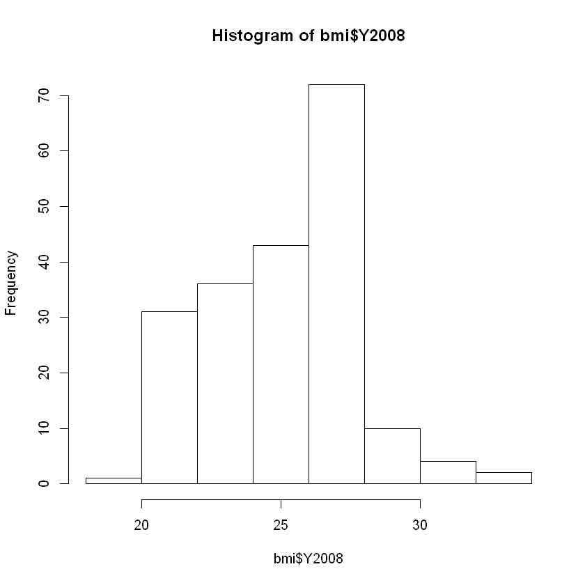

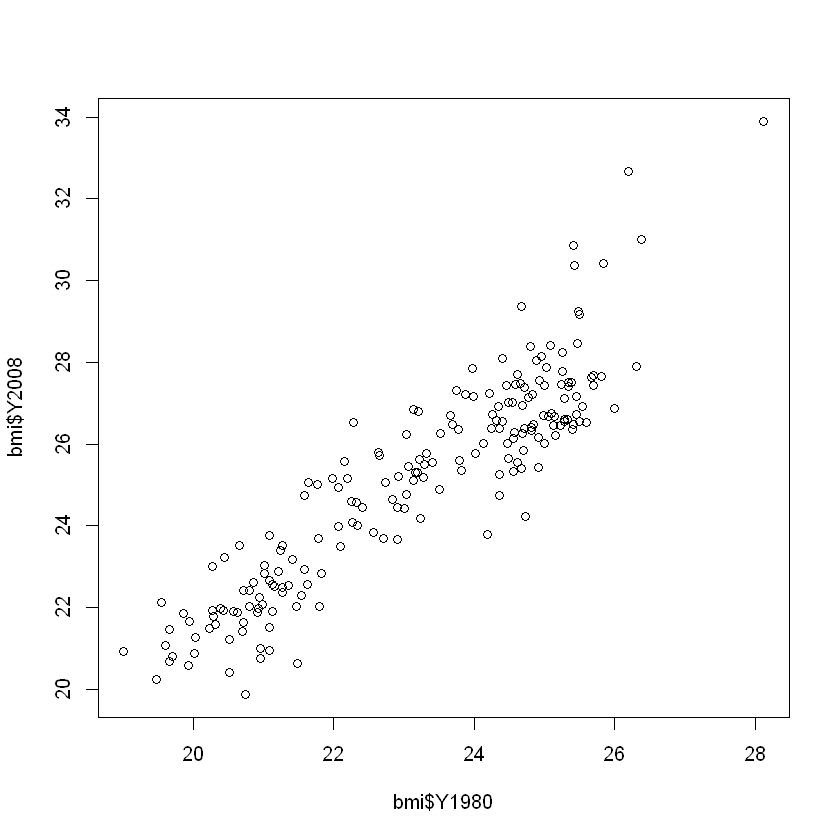

```python
# Histogram of BMIs from 2008
hist(bmi$Y2008)

# Scatter plot comparing BMIs from 1980 to those from 2008
plot(bmi$Y1980, bmi$Y2008)
```

### Spreading key-value pairs into columns

The opposite of `gather()` is `spread()`, which takes key-values pairs and spreads them across multiple columns. This is useful when values in a column should actually be column names (i.e. variables). It can also make data more compact and easier to read.

```
spread(long_df, my_key, my_val)
```

### Separating columns

The `separate()` function allows you to separate one column into multiple columns. Unless you tell it otherwise, it will attempt to separate on any character that is not a letter or number. You can also specify a specific separator using the sep argument.

treatments dataset obeys the principles of tidy data, but we'd like to split the treatment dates into two separate columns: year and month. This can be accomplished with the following:

```
separate(treatments, year_mo, c("year", "month"))
```

### Uniting columns

The opposite of separate() is unite(), which takes multiple columns and pastes them together. By default, the contents of the columns will be separated by underscores in the new column, but this behavior can be altered via the sep argument.

treatments but this time the `year_mo` column has been separated into `year` and `month`. The original column can be recreated by putting year and month back together:

```
unite(treatments, year_mo, year, month)
```

### Variables are stored in both rows and columns

Sometimes you'll run into situations where variables are stored in both rows and columns. Although it may not be immediately obvious, if we treat the values in the type column as variables and create a separate column for each of them, we can set things straight. To do this, we use the `spread()` function.

### Multiple values are stored in one column

It's also fairly common that you will find two variables stored in a single column of data. These variables may be joined by a separator like a dash, underscore, space, or forward slash.

The `separate(`) function comes in handy in these situations. Keep in mind that the `into` argument, which specifies the names of the 2 new columns being formed, must be given as a character vector (e.g. `c("column1", "column2"))`.

# Preparing data for analysis

### Type conversions

```python
# Make this evaluate to "character"
class(as.character(TRUE))

# Make this evaluate to "numeric"
class(as.numeric("8484.00"))

# Make this evaluate to "integer"
class(as.integer(99L))

# Make this evaluate to "factor"
class(as.factor("factor"))

# Make this evaluate to "logical"
class(as.logical("FALSE"))
```

'character'

'numeric'

'integer'

'factor'

'logical'

### Common type conversions

It is often necessary to change, or coerce, the way that variables in a dataset are stored.

This could be because of the way they were read into R (with `read.csv()`, for example) or perhaps the function you are using to analyze the data requires variables to be coded a certain way.

There are a few less intuitive results. For example, under the hood, the logical values `TRUE` and `FALSE` are coded as `1` and `0`, respectively. Therefore, `as.logical(1)` returns `TRUE` and `as.numeric(TRUE)` returns `1`.

### Working with dates

Dates can be a challenge to work with in any programming language, but thanks to the lubridate package, working with dates in R isn't so bad. Since this project is about cleaning data, we only cover the most basic functions from lubridate to help us standardize the format of dates and times in our data. these functions combine the letters `y`, `m`, `d`, `h`, `m`, `s`, which stand for year, month, day, hour, minute, and second, respectively. The order of the letters in the function should match the order of the date/time you are attempting to read in, although not all combinations are valid. Notice that the functions are "smart" in that they are capable of parsing multiple formats.

```python
students = read_csv('https://assets.datacamp.com/production/repositories/34/datasets/f75a87dbbdf2cf79e2286f97b2af22146cb717b1/students_with_dates.csv')
head(students)
```

| X1 | school | sex | dob | address | famsize | Pstatus | Medu | Fedu | Mjob | ... | romantic | famrel | freetime | goout | Dalc | Walc | health | nurse_visit | absences | Grades |
| --- | --- | --- | --- | --- | --- | --- | --- | --- | --- | --- | --- | --- | --- | --- | --- | --- | --- | --- | --- | --- |
| 1 | GP | F | 2000-06-05 | U | GT3 | A | 4 | 4 | at_home | ... | no | 4 | 3 | 4 | 1 | 1 | 3 | 2014-04-10 14:59:54 | 6 | 5/6/6 |
| 2 | GP | F | 1999-11-25 | U | GT3 | T | 1 | 1 | at_home | ... | no | 5 | 3 | 3 | 1 | 1 | 3 | 2015-03-12 14:59:54 | 4 | 5/5/6 |
| 3 | GP | F | 1998-02-02 | U | LE3 | T | 1 | 1 | at_home | ... | no | 4 | 3 | 2 | 2 | 3 | 3 | 2015-09-21 14:59:54 | 10 | 7/8/10 |
| 4 | GP | F | 1997-12-20 | U | GT3 | T | 4 | 2 | health | ... | yes | 3 | 2 | 2 | 1 | 1 | 5 | 2015-09-03 14:59:54 | 2 | 15/14/15 |
| 5 | GP | F | 1998-10-04 | U | GT3 | T | 3 | 3 | other | ... | no | 4 | 3 | 2 | 1 | 2 | 5 | 2015-04-07 14:59:54 | 4 | 6/10/10 |
| 6 | GP | M | 1999-06-16 | U | LE3 | T | 4 | 3 | services | ... | no | 5 | 4 | 2 | 1 | 2 | 5 | 2013-11-15 14:59:54 | 10 | 15/15/15 |

```python
str(students)
```

```
tibble [395 x 33] (S3: spec_tbl_df/tbl_df/tbl/data.frame)
 $ X1         : num [1:395] 1 2 3 4 5 6 7 8 9 10 ...
 $ school     : chr [1:395] "GP" "GP" "GP" "GP" ...
 $ sex        : chr [1:395] "F" "F" "F" "F" ...
 $ dob        : Date[1:395], format: "2000-06-05" "1999-11-25" ...
 $ address    : chr [1:395] "U" "U" "U" "U" ...
 $ famsize    : chr [1:395] "GT3" "GT3" "LE3" "GT3" ...
 $ Pstatus    : chr [1:395] "A" "T" "T" "T" ...
 $ Medu       : num [1:395] 4 1 1 4 3 4 2 4 3 3 ...
 $ Fedu       : num [1:395] 4 1 1 2 3 3 2 4 2 4 ...
 $ Mjob       : chr [1:395] "at_home" "at_home" "at_home" "health" ...
 $ Fjob       : chr [1:395] "teacher" "other" "other" "services" ...
 $ reason     : chr [1:395] "course" "course" "other" "home" ...
 $ guardian   : chr [1:395] "mother" "father" "mother" "mother" ...
 $ traveltime : num [1:395] 2 1 1 1 1 1 1 2 1 1 ...
 $ studytime  : num [1:395] 2 2 2 3 2 2 2 2 2 2 ...
 $ failures   : num [1:395] 0 0 3 0 0 0 0 0 0 0 ...
 $ schoolsup  : chr [1:395] "yes" "no" "yes" "no" ...
 $ famsup     : chr [1:395] "no" "yes" "no" "yes" ...
 $ paid       : chr [1:395] "no" "no" "yes" "yes" ...
 $ activities : chr [1:395] "no" "no" "no" "yes" ...
 $ nursery    : chr [1:395] "yes" "no" "yes" "yes" ...
 $ higher     : chr [1:395] "yes" "yes" "yes" "yes" ...
 $ internet   : chr [1:395] "no" "yes" "yes" "yes" ...
 $ romantic   : chr [1:395] "no" "no" "no" "yes" ...
 $ famrel     : num [1:395] 4 5 4 3 4 5 4 4 4 5 ...
 $ freetime   : num [1:395] 3 3 3 2 3 4 4 1 2 5 ...
 $ goout      : num [1:395] 4 3 2 2 2 2 4 4 2 1 ...
 $ Dalc       : num [1:395] 1 1 2 1 1 1 1 1 1 1 ...
 $ Walc       : num [1:395] 1 1 3 1 2 2 1 1 1 1 ...
 $ health     : num [1:395] 3 3 3 5 5 5 3 1 1 5 ...
 $ nurse_visit: POSIXct[1:395], format: "2014-04-10 14:59:54" "2015-03-12 14:59:54" ...
 $ absences   : num [1:395] 6 4 10 2 4 10 0 6 0 0 ...
 $ Grades     : chr [1:395] "5/6/6" "5/5/6" "7/8/10" "15/14/15" ...
 - attr(*, "spec")=
  .. cols(
  ..   X1 = col_double(),
  ..   school = col_character(),
  ..   sex = col_character(),
  ..   dob = col_date(format = ""),
```

[output cut: 15 more lines]

```
  ..   activities = col_character(),
  ..   nursery = col_character(),
  ..   higher = col_character(),
  ..   internet = col_character(),
  ..   romantic = col_character(),
  ..   famrel = col_double(),
  ..   freetime = col_double(),
  ..   goout = col_double(),
  ..   Dalc = col_double(),
  ..   Walc = col_double(),
  ..   health = col_double(),
  ..   nurse_visit = col_datetime(format = ""),
  ..   absences = col_double(),
  ..   Grades = col_character()
  .. )
```

```python
# Coerce Grades to character
students$Grades <- as.character(students$Grades)

# Coerce Medu to factor
students$Medu <- as.factor(students$Medu)

# Coerce Fedu to factor
students$Fedu <- as.factor(students$Fedu)

# Look at students once more with str()
str(students)
```

```
tibble [395 x 33] (S3: spec_tbl_df/tbl_df/tbl/data.frame)
 $ X1         : num [1:395] 1 2 3 4 5 6 7 8 9 10 ...
 $ school     : chr [1:395] "GP" "GP" "GP" "GP" ...
 $ sex        : chr [1:395] "F" "F" "F" "F" ...
 $ dob        : Date[1:395], format: "2000-06-05" "1999-11-25" ...
 $ address    : chr [1:395] "U" "U" "U" "U" ...
 $ famsize    : chr [1:395] "GT3" "GT3" "LE3" "GT3" ...
 $ Pstatus    : chr [1:395] "A" "T" "T" "T" ...
 $ Medu       : Factor w/ 5 levels "0","1","2","3",..: 5 2 2 5 4 5 3 5 4 4 ...
 $ Fedu       : Factor w/ 5 levels "0","1","2","3",..: 5 2 2 3 4 4 3 5 3 5 ...
 $ Mjob       : chr [1:395] "at_home" "at_home" "at_home" "health" ...
 $ Fjob       : chr [1:395] "teacher" "other" "other" "services" ...
 $ reason     : chr [1:395] "course" "course" "other" "home" ...
 $ guardian   : chr [1:395] "mother" "father" "mother" "mother" ...
 $ traveltime : num [1:395] 2 1 1 1 1 1 1 2 1 1 ...
 $ studytime  : num [1:395] 2 2 2 3 2 2 2 2 2 2 ...
 $ failures   : num [1:395] 0 0 3 0 0 0 0 0 0 0 ...
 $ schoolsup  : chr [1:395] "yes" "no" "yes" "no" ...
 $ famsup     : chr [1:395] "no" "yes" "no" "yes" ...
 $ paid       : chr [1:395] "no" "no" "yes" "yes" ...
 $ activities : chr [1:395] "no" "no" "no" "yes" ...
 $ nursery    : chr [1:395] "yes" "no" "yes" "yes" ...
 $ higher     : chr [1:395] "yes" "yes" "yes" "yes" ...
 $ internet   : chr [1:395] "no" "yes" "yes" "yes" ...
 $ romantic   : chr [1:395] "no" "no" "no" "yes" ...
 $ famrel     : num [1:395] 4 5 4 3 4 5 4 4 4 5 ...
 $ freetime   : num [1:395] 3 3 3 2 3 4 4 1 2 5 ...
 $ goout      : num [1:395] 4 3 2 2 2 2 4 4 2 1 ...
 $ Dalc       : num [1:395] 1 1 2 1 1 1 1 1 1 1 ...
 $ Walc       : num [1:395] 1 1 3 1 2 2 1 1 1 1 ...
 $ health     : num [1:395] 3 3 3 5 5 5 3 1 1 5 ...
 $ nurse_visit: POSIXct[1:395], format: "2014-04-10 14:59:54" "2015-03-12 14:59:54" ...
 $ absences   : num [1:395] 6 4 10 2 4 10 0 6 0 0 ...
 $ Grades     : chr [1:395] "5/6/6" "5/5/6" "7/8/10" "15/14/15" ...
 - attr(*, "spec")=
  .. cols(
  ..   X1 = col_double(),
  ..   school = col_character(),
  ..   sex = col_character(),
  ..   dob = col_date(format = ""),
```

[output cut: 15 more lines]

```
  ..   activities = col_character(),
  ..   nursery = col_character(),
  ..   higher = col_character(),
  ..   internet = col_character(),
  ..   romantic = col_character(),
  ..   famrel = col_double(),
  ..   freetime = col_double(),
  ..   goout = col_double(),
  ..   Dalc = col_double(),
  ..   Walc = col_double(),
  ..   health = col_double(),
  ..   nurse_visit = col_datetime(format = ""),
  ..   absences = col_double(),
  ..   Grades = col_character()
  .. )
```

```python
# Preview students2 with str()
str(students)

# Parse as date
dmy("17 Sep 2015")

# Parse as date and time (with no seconds!)
mdy_hm("July 15, 2012 12:56")

# Coerce dob to a date (with no time)
students$dob <- ymd(students$dob)

# Coerce nurse_visit to a date and time
students$nurse_visit <- ymd_hms(students$nurse_visit)

# Look at students2 once more with str()
str(students)
```

```
tibble [395 x 33] (S3: spec_tbl_df/tbl_df/tbl/data.frame)
 $ X1         : num [1:395] 1 2 3 4 5 6 7 8 9 10 ...
 $ school     : chr [1:395] "GP" "GP" "GP" "GP" ...
 $ sex        : chr [1:395] "F" "F" "F" "F" ...
 $ dob        : Date[1:395], format: "2000-06-05" "1999-11-25" ...
 $ address    : chr [1:395] "U" "U" "U" "U" ...
 $ famsize    : chr [1:395] "GT3" "GT3" "LE3" "GT3" ...
 $ Pstatus    : chr [1:395] "A" "T" "T" "T" ...
 $ Medu       : Factor w/ 5 levels "0","1","2","3",..: 5 2 2 5 4 5 3 5 4 4 ...
 $ Fedu       : Factor w/ 5 levels "0","1","2","3",..: 5 2 2 3 4 4 3 5 3 5 ...
 $ Mjob       : chr [1:395] "at_home" "at_home" "at_home" "health" ...
 $ Fjob       : chr [1:395] "teacher" "other" "other" "services" ...
 $ reason     : chr [1:395] "course" "course" "other" "home" ...
 $ guardian   : chr [1:395] "mother" "father" "mother" "mother" ...
 $ traveltime : num [1:395] 2 1 1 1 1 1 1 2 1 1 ...
 $ studytime  : num [1:395] 2 2 2 3 2 2 2 2 2 2 ...
 $ failures   : num [1:395] 0 0 3 0 0 0 0 0 0 0 ...
 $ schoolsup  : chr [1:395] "yes" "no" "yes" "no" ...
 $ famsup     : chr [1:395] "no" "yes" "no" "yes" ...
 $ paid       : chr [1:395] "no" "no" "yes" "yes" ...
 $ activities : chr [1:395] "no" "no" "no" "yes" ...
 $ nursery    : chr [1:395] "yes" "no" "yes" "yes" ...
 $ higher     : chr [1:395] "yes" "yes" "yes" "yes" ...
 $ internet   : chr [1:395] "no" "yes" "yes" "yes" ...
 $ romantic   : chr [1:395] "no" "no" "no" "yes" ...
 $ famrel     : num [1:395] 4 5 4 3 4 5 4 4 4 5 ...
 $ freetime   : num [1:395] 3 3 3 2 3 4 4 1 2 5 ...
 $ goout      : num [1:395] 4 3 2 2 2 2 4 4 2 1 ...
 $ Dalc       : num [1:395] 1 1 2 1 1 1 1 1 1 1 ...
 $ Walc       : num [1:395] 1 1 3 1 2 2 1 1 1 1 ...
 $ health     : num [1:395] 3 3 3 5 5 5 3 1 1 5 ...
 $ nurse_visit: POSIXct[1:395], format: "2014-04-10 14:59:54" "2015-03-12 14:59:54" ...
 $ absences   : num [1:395] 6 4 10 2 4 10 0 6 0 0 ...
 $ Grades     : chr [1:395] "5/6/6" "5/5/6" "7/8/10" "15/14/15" ...
 - attr(*, "spec")=
  .. cols(
  ..   X1 = col_double(),
  ..   school = col_character(),
  ..   sex = col_character(),
  ..   dob = col_date(format = ""),
```

[output cut: 15 more lines]

```
  ..   activities = col_character(),
  ..   nursery = col_character(),
  ..   higher = col_character(),
  ..   internet = col_character(),
  ..   romantic = col_character(),
  ..   famrel = col_double(),
  ..   freetime = col_double(),
  ..   goout = col_double(),
  ..   Dalc = col_double(),
  ..   Walc = col_double(),
  ..   health = col_double(),
  ..   nurse_visit = col_datetime(format = ""),
  ..   absences = col_double(),
  ..   Grades = col_character()
  .. )
```

2015-09-17

```
[1] "2012-07-15 12:56:00 UTC"
```

```
tibble [395 x 33] (S3: spec_tbl_df/tbl_df/tbl/data.frame)
 $ X1         : num [1:395] 1 2 3 4 5 6 7 8 9 10 ...
 $ school     : chr [1:395] "GP" "GP" "GP" "GP" ...
 $ sex        : chr [1:395] "F" "F" "F" "F" ...
 $ dob        : Date[1:395], format: "2000-06-05" "1999-11-25" ...
 $ address    : chr [1:395] "U" "U" "U" "U" ...
 $ famsize    : chr [1:395] "GT3" "GT3" "LE3" "GT3" ...
 $ Pstatus    : chr [1:395] "A" "T" "T" "T" ...
 $ Medu       : Factor w/ 5 levels "0","1","2","3",..: 5 2 2 5 4 5 3 5 4 4 ...
 $ Fedu       : Factor w/ 5 levels "0","1","2","3",..: 5 2 2 3 4 4 3 5 3 5 ...
 $ Mjob       : chr [1:395] "at_home" "at_home" "at_home" "health" ...
 $ Fjob       : chr [1:395] "teacher" "other" "other" "services" ...
 $ reason     : chr [1:395] "course" "course" "other" "home" ...
 $ guardian   : chr [1:395] "mother" "father" "mother" "mother" ...
 $ traveltime : num [1:395] 2 1 1 1 1 1 1 2 1 1 ...
 $ studytime  : num [1:395] 2 2 2 3 2 2 2 2 2 2 ...
 $ failures   : num [1:395] 0 0 3 0 0 0 0 0 0 0 ...
 $ schoolsup  : chr [1:395] "yes" "no" "yes" "no" ...
 $ famsup     : chr [1:395] "no" "yes" "no" "yes" ...
 $ paid       : chr [1:395] "no" "no" "yes" "yes" ...
 $ activities : chr [1:395] "no" "no" "no" "yes" ...
 $ nursery    : chr [1:395] "yes" "no" "yes" "yes" ...
 $ higher     : chr [1:395] "yes" "yes" "yes" "yes" ...
 $ internet   : chr [1:395] "no" "yes" "yes" "yes" ...
 $ romantic   : chr [1:395] "no" "no" "no" "yes" ...
 $ famrel     : num [1:395] 4 5 4 3 4 5 4 4 4 5 ...
 $ freetime   : num [1:395] 3 3 3 2 3 4 4 1 2 5 ...
 $ goout      : num [1:395] 4 3 2 2 2 2 4 4 2 1 ...
 $ Dalc       : num [1:395] 1 1 2 1 1 1 1 1 1 1 ...
 $ Walc       : num [1:395] 1 1 3 1 2 2 1 1 1 1 ...
 $ health     : num [1:395] 3 3 3 5 5 5 3 1 1 5 ...
 $ nurse_visit: POSIXct[1:395], format: "2014-04-10 14:59:54" "2015-03-12 14:59:54" ...
 $ absences   : num [1:395] 6 4 10 2 4 10 0 6 0 0 ...
 $ Grades     : chr [1:395] "5/6/6" "5/5/6" "7/8/10" "15/14/15" ...
 - attr(*, "spec")=
  .. cols(
  ..   X1 = col_double(),
  ..   school = col_character(),
  ..   sex = col_character(),
  ..   dob = col_date(format = ""),
```

[output cut: 15 more lines]

```
  ..   activities = col_character(),
  ..   nursery = col_character(),
  ..   higher = col_character(),
  ..   internet = col_character(),
  ..   romantic = col_character(),
  ..   famrel = col_double(),
  ..   freetime = col_double(),
  ..   goout = col_double(),
  ..   Dalc = col_double(),
  ..   Walc = col_double(),
  ..   health = col_double(),
  ..   nurse_visit = col_datetime(format = ""),
  ..   absences = col_double(),
  ..   Grades = col_character()
  .. )
```

## String manipulation

### Trimming and padding strings

One common issue that comes up when cleaning data is the need to remove leading and/or trailing white space. The `str_trim()` function from stringr makes it easy to do this while leaving intact the part of the string that you actually want.

```
> str_trim("  this is a test     ")
[1] "this is a test"
```

A similar issue is when you need to pad strings to make them a certain number of characters wide. One example is if you had a bunch of employee ID numbers, some of which begin with one or more zeros. When reading these data in, you find that the leading zeros have been dropped somewhere along the way (probably because the variable was thought to be numeric and in that case, leading zeros would be unnecessary.)

```
> str_pad("24493", width = 7, side = "left", pad = "0")
[1] "0024493"
```

```python
# Load the stringr package
library(stringr)

# Trim all leading and trailing whitespace
str_trim(c("   Filip ", "Nick  ", " Jonathan"))

# Pad these strings with leading zeros
str_pad(c("23485W", "8823453Q", "994Z"), width=9, side='left', pad='0')
```

<ol class=list-inline>

'Filip'

'Nick'

'Jonathan'

</ol>

<ol class=list-inline>

'00023485W'

'08823453Q'

'00000994Z'

</ol>

> Examples like this are certainly handy in R. For example, the `str_pad()` function is useful when importing a dataset with US zip codes. Occasionally R will drop the leading 0 in a zipcode, thinking it's numeric.

### Upper and lower case

In addition to trimming and padding strings, you may need to adjust their case from time to time. Making strings uppercase or lowercase is very straightforward in (base) R thanks to `toupper()` and `tolower()`. Each function takes exactly one argument:the character string (or vector/column of strings) to be converted to the desired case.

```python
states <- c("al", "ak", "az", "ar", "ca", "co", "ct", "de", "fl", "ga", "hi", "id", "il", "in", "ia", "ks", "ky", "la", "me", "md", "ma", "mi", "mn", "ms", "mo", "mt", "ne", "nv", "nh", "nj", "nm", "ny", "nc", "nd", "oh", "ok", "or", "pa", "ri", "sc", "sd", "tn", "tx", "ut", "vt", "va", "wa", "wv", "wi", "wy")
# Print state abbreviations
states

# Make states all uppercase and save result to states_upper
states_upper <- toupper(states)
states_upper

# Make states_upper all lowercase again
tolower(states_upper)
```

<ol class=list-inline>

'al'

'ak'

'az'

'ar'

'ca'

'co'

'ct'

'de'

'fl'

'ga'

'hi'

'id'

'il'

'in'

'ia'

'ks'

'ky'

'la'

'me'

'md'

'ma'

'mi'

'mn'

'ms'

'mo'

'mt'

'ne'

'nv'

'nh'

'nj'

'nm'

'ny'

'nc'

'nd'

'oh'

'ok'

'or'

'pa'

'ri'

'sc'

'sd'

'tn'

'tx'

'ut'

'vt'

'va'

'wa'

'wv'

'wi'

'wy'

</ol>

<ol class=list-inline>

'AL'

'AK'

'AZ'

'AR'

'CA'

'CO'

'CT'

'DE'

'FL'

'GA'

'HI'

'ID'

'IL'

'IN'

'IA'

'KS'

'KY'

'LA'

'ME'

'MD'

'MA'

'MI'

'MN'

'MS'

'MO'

'MT'

'NE'

'NV'

'NH'

'NJ'

'NM'

'NY'

'NC'

'ND'

'OH'

'OK'

'OR'

'PA'

'RI'

'SC'

'SD'

'TN'

'TX'

'UT'

'VT'

'VA'

'WA'

'WV'

'WI'

'WY'

</ol>

<ol class=list-inline>

'al'

'ak'

'az'

'ar'

'ca'

'co'

'ct'

'de'

'fl'

'ga'

'hi'

'id'

'il'

'in'

'ia'

'ks'

'ky'

'la'

'me'

'md'

'ma'

'mi'

'mn'

'ms'

'mo'

'mt'

'ne'

'nv'

'nh'

'nj'

'nm'

'ny'

'nc'

'nd'

'oh'

'ok'

'or'

'pa'

'ri'

'sc'

'sd'

'tn'

'tx'

'ut'

'vt'

'va'

'wa'

'wv'

'wi'

'wy'

</ol>

### Finding and replacing strings

The stringr package provides two functions that are very useful for finding and/or replacing patterns in strings: `str_detect()` and `str_replace()`.

Like all functions in stringr, the first argument of each is the string of interest. The second argument of each is the pattern of interest. In the case of `str_detect()`, this is the pattern we are searching for. In the case of `str_replace()`, this is the pattern we want to replace. Finally, `str_replace()` has a third argument, which is the string to replace with.

```
> str_detect(c("banana", "kiwi"), "a")
[1]  TRUE FALSE
> str_replace(c("banana", "kiwi"), "a", "o")
[1] "bonana" "kiwi"
```

```python
# Copy of students2: students3
students3 <- students

# Look at the head of students3
head(students3)

# Detect all dates of birth (dob) in 1997
str_detect(students3$dob, "1997")

# In the sex column, replace "F" with "Female" ...
students3$sex <- str_replace(students3$sex, "F", "Female")

# ... and "M" with "Male"
students3$sex <- str_replace(students3$sex, "M", "Male")

# View the head of students3
head(students3)
```

| X1 | school | sex | dob | address | famsize | Pstatus | Medu | Fedu | Mjob | ... | romantic | famrel | freetime | goout | Dalc | Walc | health | nurse_visit | absences | Grades |
| --- | --- | --- | --- | --- | --- | --- | --- | --- | --- | --- | --- | --- | --- | --- | --- | --- | --- | --- | --- | --- |
| 1 | GP | F | 2000-06-05 | U | GT3 | A | 4 | 4 | at_home | ... | no | 4 | 3 | 4 | 1 | 1 | 3 | 2014-04-10 14:59:54 | 6 | 5/6/6 |
| 2 | GP | F | 1999-11-25 | U | GT3 | T | 1 | 1 | at_home | ... | no | 5 | 3 | 3 | 1 | 1 | 3 | 2015-03-12 14:59:54 | 4 | 5/5/6 |
| 3 | GP | F | 1998-02-02 | U | LE3 | T | 1 | 1 | at_home | ... | no | 4 | 3 | 2 | 2 | 3 | 3 | 2015-09-21 14:59:54 | 10 | 7/8/10 |
| 4 | GP | F | 1997-12-20 | U | GT3 | T | 4 | 2 | health | ... | yes | 3 | 2 | 2 | 1 | 1 | 5 | 2015-09-03 14:59:54 | 2 | 15/14/15 |
| 5 | GP | F | 1998-10-04 | U | GT3 | T | 3 | 3 | other | ... | no | 4 | 3 | 2 | 1 | 2 | 5 | 2015-04-07 14:59:54 | 4 | 6/10/10 |
| 6 | GP | M | 1999-06-16 | U | LE3 | T | 4 | 3 | services | ... | no | 5 | 4 | 2 | 1 | 2 | 5 | 2013-11-15 14:59:54 | 10 | 15/15/15 |

<ol class=list-inline>

FALSE

FALSE

FALSE

TRUE

FALSE

FALSE

TRUE

FALSE

FALSE

TRUE

FALSE

FALSE

FALSE

TRUE

FALSE

FALSE

TRUE

FALSE

FALSE

FALSE

FALSE

FALSE

TRUE

TRUE

TRUE

FALSE

FALSE

TRUE

FALSE

FALSE

FALSE

FALSE

FALSE

FALSE

TRUE

FALSE

TRUE

FALSE

FALSE

FALSE

FALSE

TRUE

TRUE

FALSE

FALSE

FALSE

TRUE

TRUE

TRUE

TRUE

TRUE

FALSE

FALSE

FALSE

FALSE

FALSE

TRUE

TRUE

FALSE

FALSE

FALSE

FALSE

FALSE

FALSE

FALSE

FALSE

FALSE

TRUE

FALSE

FALSE

TRUE

FALSE

FALSE

FALSE

FALSE

FALSE

FALSE

FALSE

FALSE

FALSE

TRUE

FALSE

FALSE

TRUE

FALSE

FALSE

FALSE

TRUE

FALSE

FALSE

TRUE

TRUE

FALSE

TRUE

FALSE

TRUE

TRUE

FALSE

TRUE

TRUE

FALSE

FALSE

FALSE

FALSE

FALSE

FALSE

FALSE

FALSE

FALSE

FALSE

FALSE

FALSE

FALSE

TRUE

FALSE

TRUE

FALSE

FALSE

FALSE

FALSE

TRUE

TRUE

FALSE

FALSE

FALSE

FALSE

TRUE

FALSE

FALSE

FALSE

FALSE

TRUE

FALSE

FALSE

FALSE

FALSE

TRUE

FALSE

FALSE

FALSE

TRUE

FALSE

FALSE

TRUE

FALSE

TRUE

FALSE

FALSE

TRUE

TRUE

FALSE

FALSE

FALSE

TRUE

FALSE

FALSE

FALSE

FALSE

FALSE

FALSE

FALSE

FALSE

TRUE

FALSE

TRUE

TRUE

TRUE

FALSE

FALSE

FALSE

FALSE

TRUE

TRUE

TRUE

FALSE

FALSE

FALSE

FALSE

FALSE

FALSE

TRUE

FALSE

FALSE

FALSE

FALSE

FALSE

TRUE

FALSE

TRUE

TRUE

TRUE

TRUE

FALSE

FALSE

FALSE

FALSE

FALSE

FALSE

FALSE

FALSE

FALSE

FALSE

FALSE

FALSE

FALSE

FALSE

FALSE

FALSE

FALSE

TRUE

FALSE

FALSE

FALSE

FALSE

FALSE

FALSE

FALSE

TRUE

FALSE

TRUE

FALSE

FALSE

FALSE

FALSE

FALSE

TRUE

TRUE

FALSE

FALSE

FALSE

FALSE

FALSE

FALSE

FALSE

FALSE

FALSE

FALSE

FALSE

TRUE

FALSE

FALSE

FALSE

FALSE

FALSE

FALSE

FALSE

FALSE

FALSE

FALSE

TRUE

FALSE

FALSE

FALSE

FALSE

FALSE

FALSE

FALSE

FALSE

FALSE

FALSE

FALSE

FALSE

FALSE

FALSE

FALSE

FALSE

FALSE

FALSE

FALSE

FALSE

FALSE

FALSE

FALSE

FALSE

FALSE

FALSE

TRUE

FALSE

FALSE

FALSE

FALSE

TRUE

FALSE

TRUE

FALSE

FALSE

FALSE

FALSE

FALSE

FALSE

FALSE

FALSE

FALSE

TRUE

FALSE

FALSE

FALSE

TRUE

FALSE

FALSE

FALSE

FALSE

FALSE

FALSE

FALSE

FALSE

FALSE

FALSE

FALSE

FALSE

FALSE

FALSE

FALSE

FALSE

FALSE

FALSE

FALSE

FALSE

FALSE

FALSE

FALSE

FALSE

FALSE

FALSE

FALSE

FALSE

FALSE

TRUE

FALSE

TRUE

FALSE

FALSE

TRUE

FALSE

FALSE

FALSE

FALSE

FALSE

FALSE

TRUE

FALSE

FALSE

TRUE

FALSE

FALSE

TRUE

FALSE

TRUE

TRUE

FALSE

FALSE

FALSE

FALSE

FALSE

FALSE

FALSE

TRUE

FALSE

FALSE

TRUE

FALSE

TRUE

TRUE

FALSE

FALSE

FALSE

FALSE

FALSE

FALSE

FALSE

FALSE

FALSE

FALSE

TRUE

TRUE

TRUE

FALSE

FALSE

FALSE

FALSE

TRUE

TRUE

TRUE

TRUE

FALSE

FALSE

FALSE

FALSE

FALSE

FALSE

FALSE

FALSE

FALSE

FALSE

FALSE

</ol>

| X1 | school | sex | dob | address | famsize | Pstatus | Medu | Fedu | Mjob | ... | romantic | famrel | freetime | goout | Dalc | Walc | health | nurse_visit | absences | Grades |
| --- | --- | --- | --- | --- | --- | --- | --- | --- | --- | --- | --- | --- | --- | --- | --- | --- | --- | --- | --- | --- |
| 1 | GP | Female | 2000-06-05 | U | GT3 | A | 4 | 4 | at_home | ... | no | 4 | 3 | 4 | 1 | 1 | 3 | 2014-04-10 14:59:54 | 6 | 5/6/6 |
| 2 | GP | Female | 1999-11-25 | U | GT3 | T | 1 | 1 | at_home | ... | no | 5 | 3 | 3 | 1 | 1 | 3 | 2015-03-12 14:59:54 | 4 | 5/5/6 |
| 3 | GP | Female | 1998-02-02 | U | LE3 | T | 1 | 1 | at_home | ... | no | 4 | 3 | 2 | 2 | 3 | 3 | 2015-09-21 14:59:54 | 10 | 7/8/10 |
| 4 | GP | Female | 1997-12-20 | U | GT3 | T | 4 | 2 | health | ... | yes | 3 | 2 | 2 | 1 | 1 | 5 | 2015-09-03 14:59:54 | 2 | 15/14/15 |
| 5 | GP | Female | 1998-10-04 | U | GT3 | T | 3 | 3 | other | ... | no | 4 | 3 | 2 | 1 | 2 | 5 | 2015-04-07 14:59:54 | 4 | 6/10/10 |
| 6 | GP | Male | 1999-06-16 | U | LE3 | T | 4 | 3 | services | ... | no | 5 | 4 | 2 | 1 | 2 | 5 | 2013-11-15 14:59:54 | 10 | 15/15/15 |

## Missing and special values

### Finding missing values

```python
social_df = data.frame(name=c('Sarah', 'Tom', 'David', 'Alice'), n_friends=c(244,NA,145,43),status=c('going out', "",'Movie Night', ""))
```

```python
# Call is.na() on the full social_df to spot all NAs
is.na(social_df)

# Use the any() function to ask whether there are any NAs in the data
any(is.na(social_df))

# View a summary() of the dataset
summary(social_df)

# Call table() on the status column
table(social_df$status)
```

| name | n_friends | status |
| --- | --- | --- |
| FALSE | FALSE | FALSE |
| FALSE | TRUE | FALSE |
| FALSE | FALSE | FALSE |
| FALSE | FALSE | FALSE |

TRUE

```
    name     n_friends             status
 Alice:1   Min.   : 43.0              :2
 David:1   1st Qu.: 94.0   going out  :1
 Sarah:1   Median :145.0   Movie Night:1
 Tom  :1   Mean   :144.0
           3rd Qu.:194.5
           Max.   :244.0
           NA's   :1
```

```
              going out Movie Night
          2           1           1
```

### Dealing with missing values

Missing values can be a rather complex subject, but here we'll only look at the simple case where you are simply interested in normalizing and/or removing all missing values from your data. For more information on why this is not always the best strategy, search online for "missing not at random."

Looking at the `social_df` dataset again, we asked around a bit and figured out what's causing the missing values that you saw in the last exercise. Tom doesn't have a social media account on this particular platform, which explains why his number of friends and current status are missing (although coded in two different ways). Alice is on the platform, but is a passive user and never sets her status, hence the reason it's missing for her.

```python
# Replace all empty strings in status with NA
social_df$status[social_df$status == ""] <- NA

# Print social_df to the console
social_df

# Use complete.cases() to see which rows have no missing values
complete.cases(social_df)

# Use na.omit() to remove all rows with any missing values
na.omit(social_df)
```

| name | n_friends | status |
| --- | --- | --- |
| Sarah | 244 | going out |
| Tom | NA | NA |
| David | 145 | Movie Night |
| Alice | 43 | NA |

<ol class=list-inline>

TRUE

FALSE

TRUE

FALSE

</ol>

|  | name | n_friends | status |
| --- | --- | --- | --- |
| 1 | Sarah | 244 | going out |
| 3 | David | 145 | Movie Night |

## Outliers and obvious errors

### Dealing with outliers and obvious errors

When dealing with strange values in your data, you often must decide whether they are just extreme or actually erroneous. Extreme values show up all over the place, but you, the data analyst, must figure out when they are plausible and when they are not.

```
       X1           school              sex                 dob
 Min.   :  1.0   Length:395         Length:395         Min.   :1996-11-02
 1st Qu.: 99.5   Class :character   Class :character   1st Qu.:1997-11-04
 Median :198.0   Mode  :character   Mode  :character   Median :1998-12-16
 Mean   :198.0                                         Mean   :1998-10-30
 3rd Qu.:296.5                                         3rd Qu.:1999-10-29
 Max.   :395.0                                         Max.   :2000-10-25
   address            famsize            Pstatus          Medu    Fedu
 Length:395         Length:395         Length:395         0:  3   0:  2
 Class :character   Class :character   Class :character   1: 59   1: 82
 Mode  :character   Mode  :character   Mode  :character   2:103   2:115
                                                          3: 99   3:100
                                                          4:131   4: 96

     Mjob               Fjob              reason            guardian
 Length:395         Length:395         Length:395         Length:395
 Class :character   Class :character   Class :character   Class :character
 Mode  :character   Mode  :character   Mode  :character   Mode  :character



   traveltime      studytime        failures       schoolsup
 Min.   :1.000   Min.   :1.000   Min.   :0.0000   Length:395
 1st Qu.:1.000   1st Qu.:1.000   1st Qu.:0.0000   Class :character
 Median :1.000   Median :2.000   Median :0.0000   Mode  :character
 Mean   :1.448   Mean   :2.035   Mean   :0.3342
 3rd Qu.:2.000   3rd Qu.:2.000   3rd Qu.:0.0000
 Max.   :4.000   Max.   :4.000   Max.   :3.0000
    famsup              paid            activities          nursery
 Length:395         Length:395         Length:395         Length:395
 Class :character   Class :character   Class :character   Class :character
 Mode  :character   Mode  :character   Mode  :character   Mode  :character



    higher            internet           romantic             famrel
 Length:395         Length:395         Length:395         Min.   :1.000
 Class :character   Class :character   Class :character   1st Qu.:4.000
 Mode  :character   Mode  :character   Mode  :character   Median :4.000
                                                          Mean   :3.944
                                                          3rd Qu.:5.000
                                                          Max.   :5.000
    freetime         goout            Dalc            Walc
 Min.   :1.000   Min.   :1.000   Min.   :1.000   Min.   :1.000
 1st Qu.:3.000   1st Qu.:2.000   1st Qu.:1.000   1st Qu.:1.000
 Median :3.000   Median :3.000   Median :1.000   Median :2.000
 Mean   :3.235   Mean   :3.109   Mean   :1.481   Mean   :2.291
 3rd Qu.:4.000   3rd Qu.:4.000   3rd Qu.:2.000   3rd Qu.:3.000
 Max.   :5.000   Max.   :5.000   Max.   :5.000   Max.   :5.000
     health       nurse_visit                     absences
 Min.   :1.000   Min.   :2013-10-28 14:59:54   Min.   : 0.000
 1st Qu.:3.000   1st Qu.:2014-04-07 02:59:54   1st Qu.: 0.000
 Median :4.000   Median :2014-09-15 14:59:54   Median : 4.000
 Mean   :3.554   Mean   :2014-10-10 05:31:11   Mean   : 5.709
 3rd Qu.:5.000   3rd Qu.:2015-04-08 02:59:54   3rd Qu.: 8.000
 Max.   :5.000   Max.   :2015-10-15 14:59:54   Max.   :75.000
    Grades
 Length:395
 Class :character
 Mode  :character
```

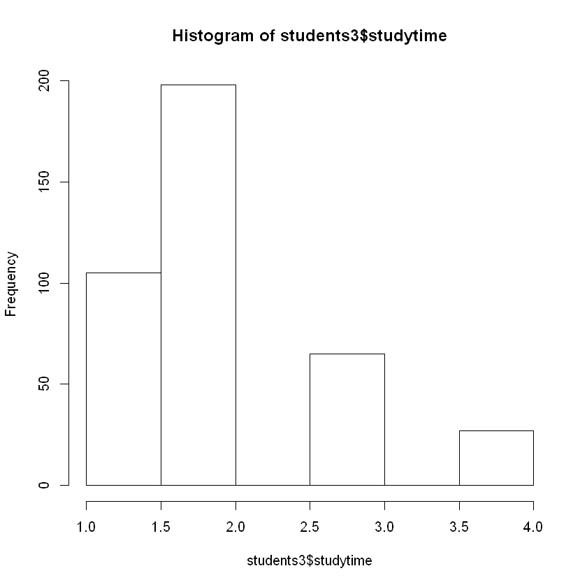

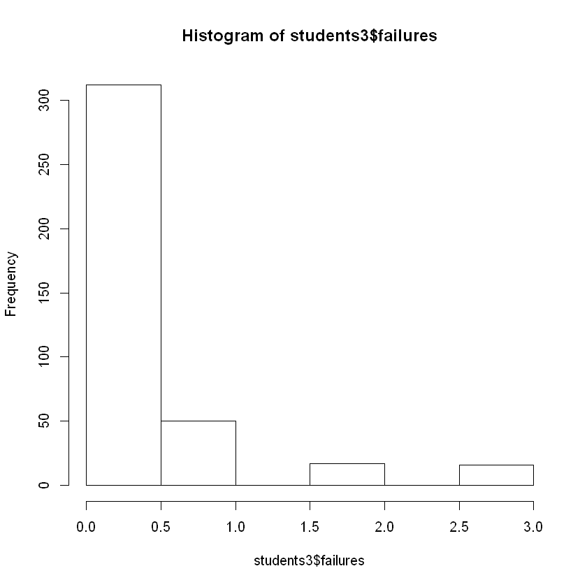

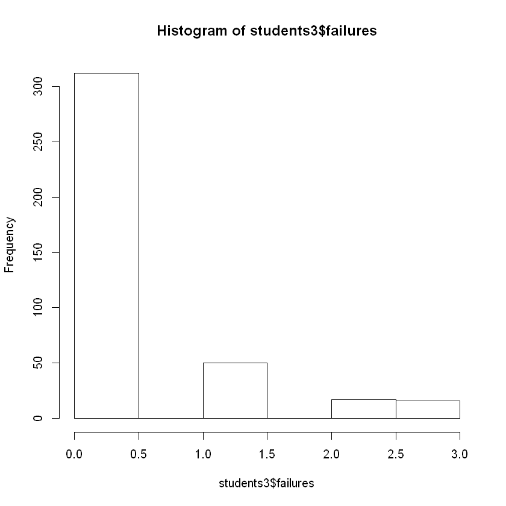

```python
# Look at a summary() of students3
summary(students3)

# View a histogram of the studytime variable
hist(students3$studytime)

# View a histogram of the failures variable
hist(students3$failures)

# View a histogram of absences, but force zeros to be bucketed to the right of zero
hist(students3$failures, right=FALSE)
```

### Another look at strange values

Another useful way of looking at strange values is with boxplots. Simply put, boxplots draw a box around the middle 50% of values for a given variable, with a bolded horizontal line drawn at the median. Values that fall far from the bulk of the data points (i.e. outliers) are denoted by open circles.

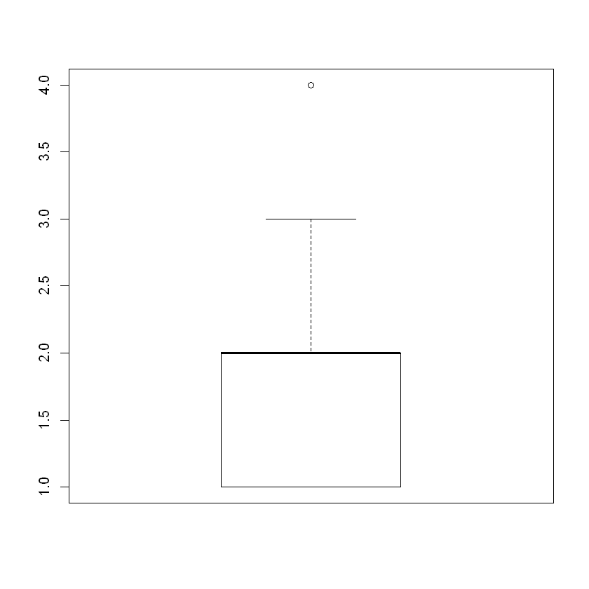

```python
boxplot(students3$studytime)
```